# S-109A Introduction to Data Science:

## Question 8: Visualize Decision Boundaries

The following code will allow you to visualize the decision boundaries of a given classification model.

```python
#--------  plot_decision_boundary
# A function that visualizes the data and the decision boundaries
# Input:
#      x (predictors)
#      y (labels)
#      model (the classifier you want to visualize)
#      title (title for plot)
#      ax (a set of axes to plot on)
#      poly_degree (highest degree of polynomial terms included in the model; None by default)

def plot_decision_boundary(x, y, model, title, ax, poly_degree=None):
    # Create mesh
    # Interval of points for biomarker 1
    min0 = x[:,0].min()
    max0 = x[:,0].max()
    interval0 = np.arange(min0, max0, (max0-min0)/100)
    n0 = np.size(interval0)

    # Interval of points for biomarker 2
    min1 = x[:,1].min()
    max1 = x[:,1].max()
    interval1 = np.arange(min1, max1, (max1-min1)/100)
    n1 = np.size(interval1)

    # Create mesh grid of points
    x1, x2 = np.meshgrid(interval0, interval1)
    x1 = x1.reshape(-1,1)
    x2 = x2.reshape(-1,1)
    xx = np.concatenate((x1, x2), axis=1)

    # Predict on mesh of points
    # Check if polynomial terms need to be included
    if(poly_degree!=None):
        # Use PolynomialFeatures to generate polynomial terms
        poly = PolynomialFeatures(poly_degree,include_bias = True)
        xx_ = poly.fit_transform(xx)
        yy = model.predict(xx_)

    else:
        yy = model.predict(xx)

    yy = yy.reshape((n0, n1))

    # Plot decision surface
    x1 = x1.reshape(n0, n1)
    x2 = x2.reshape(n0, n1)
    ax.contourf(x1, x2, yy, cmap=plt.cm.coolwarm, alpha=0.8)

    # Plot scatter plot of data
    yy = y.reshape(-1,)
    ax.scatter(x[yy==1,0], x[yy==1,1], c='blue', label='Normal', cmap=plt.cm.coolwarm)
    ax.scatter(x[yy==2,0], x[yy==2,1], c='cyan', label='Hyper', cmap=plt.cm.coolwarm)
    ax.scatter(x[yy==3,0], x[yy==3,1], c='red', label='Hypo', cmap=plt.cm.coolwarm)

    # Label axis, title
    ax.set_title(title, fontsize=16)
    ax.set_xlabel('Biomarker 1')
    ax.set_ylabel('Biomarker 2')
```

**Note:** The provided code uses `sklearn`'s `PolynomialFeatures` to generate higher-order polynomial terms, with degree `poly_degree`. Also, if you have loaded the data sets into `pandas` data frames, you may use the `as_matrix` function to obtain a `numpy` array from the data frame objects.

1. Use the above code to visualize the decision boundaries for each of the model fitted in the previous question.
2. Comment on the difference in the decision boundaries (if any) for the OvR and multinomial logistic regression models. Is there a difference between the decision boundaries for the linear logistic regression models and LDA. What about the decision boundaries for the quadratic logistic regression and QDA? Give an explanation for your answer.
3. QDA is a generalization of the LDA model. What's the primary difference that makes QDA more general? How does that manifest in the plots you generated?

#### Answers:

**8.1:** Use the above code to visualize the decision boundaries for each of the model fitted in the previous question.

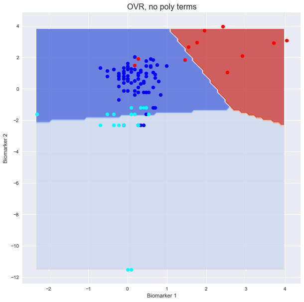

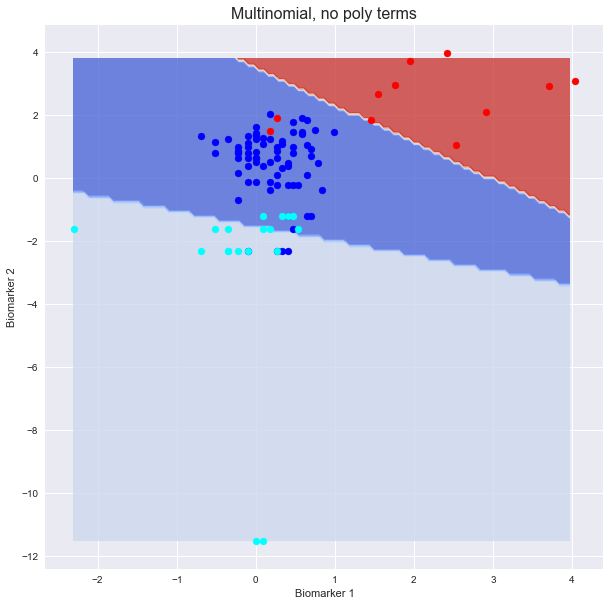

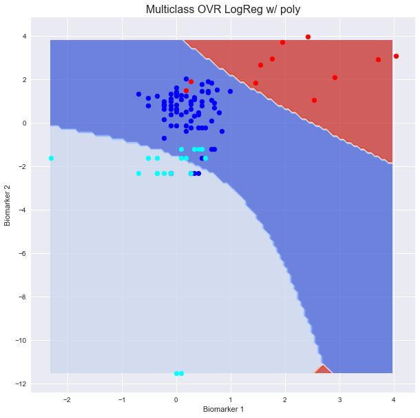

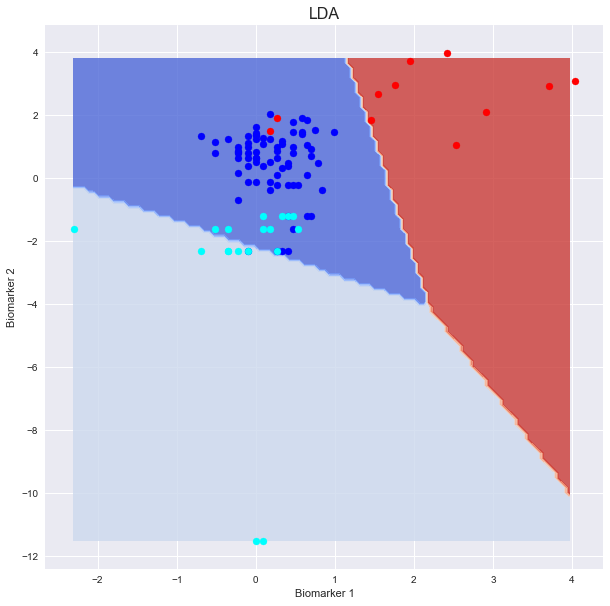

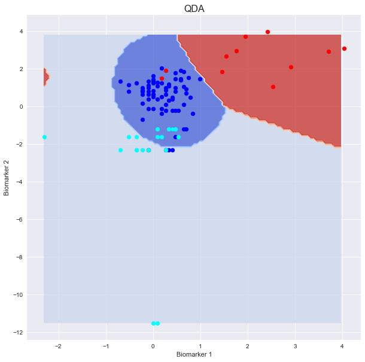

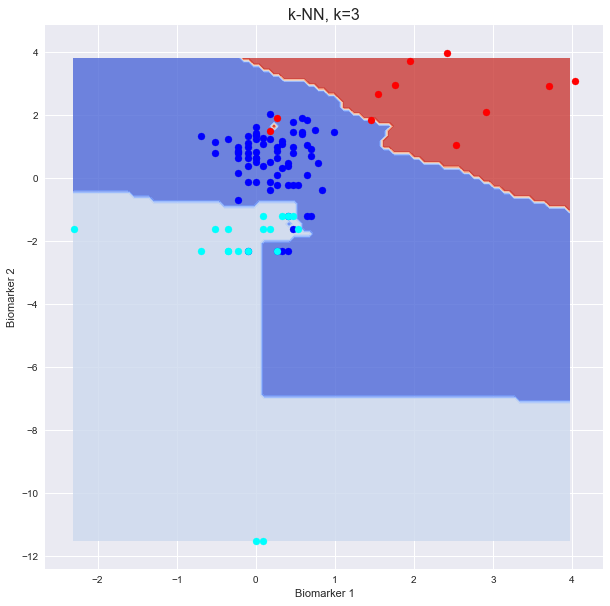

```python
xtest1 = xtest.values
xtrain1 = xtrain.values
ytest1 = ytest.values
ytrain1 = ytrain.values

ovr = LogisticRegression(C=1 ,solver='newton-cg', multi_class='ovr')
ovr_fitted = ovr.fit(xtrain,ytrain)

fig, ax = plt.subplots(figsize=(10,10))
title = 'OVR, no poly terms'
plot_decision_boundary(xtrain1, ytrain1, ovr_fitted, title, ax, poly_degree=None)

mn = LogisticRegression(C=1 ,solver='newton-cg', multi_class='multinomial')
mn_fitted = mn.fit(xtrain,ytrain)

fig, ax = plt.subplots(figsize=(10,10))
title = 'Multinomial, no poly terms'
plot_decision_boundary(xtrain1, ytrain1, mn_fitted, title, ax, poly_degree=None)

fitted = LogisticRegression(C=1, solver='newton-cg', multi_class='ovr')
fitted_multi = fitted.fit(xtrainpoly, ytrain)

fig, ax = plt.subplots(figsize=(10,10))
title = 'Multiclass OVR LogReg w/ poly'
plot_decision_boundary(xtrain1, ytrain1, fitted_multi, title, ax, poly_degree=2)

fig, ax = plt.subplots(figsize=(10,10))
title = 'LDA'
plot_decision_boundary(xtrain1, ytrain1, fitted_lda, title, ax, poly_degree=None)

fig, ax = plt.subplots(figsize=(10,10))
title = 'QDA'
plot_decision_boundary(xtrain1, ytrain1, fitted_qda, title, ax, poly_degree=None)

fig, ax = plt.subplots(figsize=(10,10))
title = 'k-NN, k=3'
plot_decision_boundary(xtrain1, ytrain1, optimal_knn, title, ax, poly_degree=None)
```

**8.2:** Comment on the difference in the decision boundaries (if any) for the OvR and multinomial logistic regression models. Is there a difference between the decision boundaries for the linear logistic regression models and LDA. What about the decision boundaries for the quadratic logistic regression and QDA? Give an explanation for your answer.

Looking at the difference between OvR and multinomial (no poly terms), it looks like the decsision boundaries for the multinomial are parallel from one another, whereas OVR produces completely different boundaries. This is odd, even though they gave us the same classification scores earlier. The reason for this difference is due to the mathematical equation that multinomial logreg comes from. All the probabilites of multinomial logreg also add up to one. Not the case for ovr. Multinomial sets one of the categores in the response variable as the reference group, and then fits seperate logreg models to predict other cases based off of it.

resource: https://stats.stackexchange.com/questions/310904/in-multinomial-logistic-regression-why-do-the-decision-boundaries-tend-to-be-pa

Yes, there is a difference between the linear logistic regression model boundary graph and the one for LDA. They both produce linear desicison boundaries, but the one for LDA is slightly different. This is because LDA takes a different appraoch than logreg. LDA models the distribution of the predictors X given the categories that Y takes on. Linear coeffs are estimated differently. MLE for logistic models is based on Gaussian assumptions for LDA. LDA makes more restrictive Gaussian assumptions.

resource: class pdf notes and http://people.math.umass.edu/~anna/stat697F/Chapter4_2.pdf

Looking at quadratic vs QDA, they do not take on linear boundaries. The quadratic graph uses OVR with poly terms of two degrees, whereas QDA does not specify. If we notice the boundaries for QDA, around the dark blue points, the blue boundary is nearly circular. This is due to the equation for QDA, based on its predictors, that it maximizes over the K classes.

resource: class pdf notes

**8.3:** QDA is a generalization of the LDA model. What's the primary difference that makes QDA more general? How does that manifest in the plots you generated?

The primary difference between QDA and LDA is that LDA assumes the covariances of the MVN (multivariate normal distribution) distributions within classes to be equal, whereas in QDA, they are allowed to be different. This allows the expression to become quadratic.

We see this in our graph from the linearity of the descision boundaries. For LDA, all the boundaries are linear; no curves, whereas for QDA, they are not linear at all. The boundaries are allowed to be quadratic and non-linear.